# Anomaly Detection

## Univariate Outlier Detection

In the example below we create a vector `x` with 100 entries sampled from the standard normal distribution

```r
# set a seed for reproducibility
set.seed(3147)
# use rnorm() to sample
x <- rnorm(100)
```

Obtain a summary of `x`:

```r
summary(x)
```

```
   Min. 1st Qu.  Median    Mean 3rd Qu.    Max.
-3.3154 -0.4837  0.1867  0.1098  0.7120  2.6859
```

We can get outliers using the `boxplot()` function

```r
# outliers
boxplot.stats(x)$out
```

```
[1] -3.315391  2.685922 -3.055717  2.571203
```

Visualize:

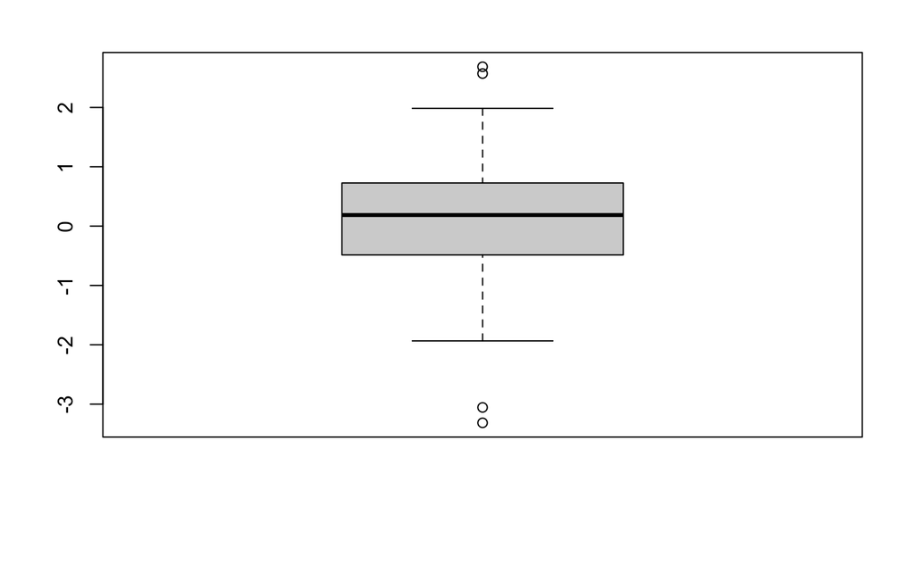

```r
boxplot(x)
```

The above univariate outlier detection can be used to find outliers in multivariate data in a simple ensemble way.

In the example below, we first generate a dataframe `df`, which has two columns, `x` and `y`. After that, outliers are detected separately from `x` and `y`. We then take outliers as those data which are outliers for both columns.

```r
# create vector with samples from the normal distribution
y <- rnorm(100)
# create data frame with x and y
df <- data.frame(x, y)
# print first 6 rows
head(df)
```

|  | x | y |
| --- | --- | --- |
| 1 | -3.31539150 | 0.7619774 |
| 2 | -0.04765067 | -0.6404403 |
| 3 | 0.69720806 | 0.7645655 |
| 4 | 0.35979073 | 0.3131930 |
| 5 | 0.18644193 | 0.1709528 |
| 6 | 0.27493834 | -0.8441813 |

Check outliers in first dimension:

```r
# find the index of outliers from x
a <- which(x %in% boxplot.stats(x)$out)
```

Find outliers in second dimension:

```r
# find the index of outliers from y
b <- which(y %in% boxplot.stats(y)$out)
```

To get outliers in both, use the `intersect()` function:

```r
# outliers in both x and y
outlier_list_1 <- intersect(a, b)
```

Visualize:

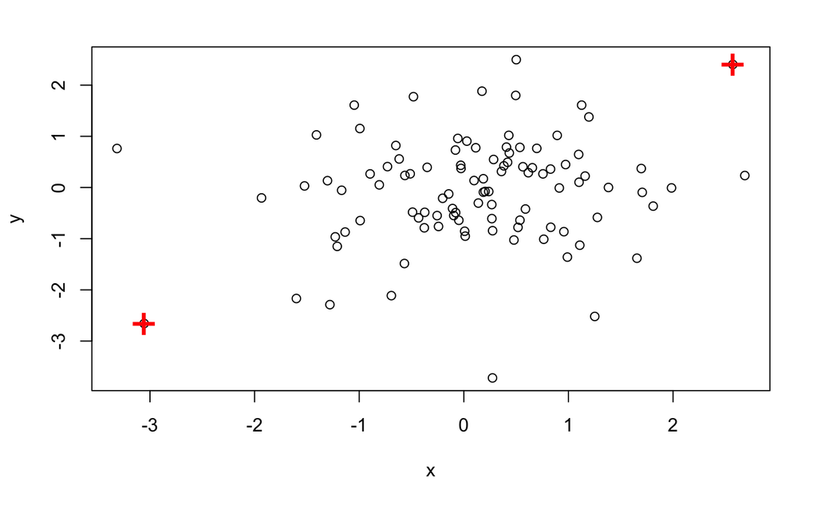

```r
plot(df)
points(df[outlier_list_1,],
       col = "red", pch = "+", cex = 2.5)
```

Similarly, we can also take outliers as those data which are outliers in *either* `x` or `y`, using the `union()` function:

```r
# outliers in either x or y
outlier_list_2 <- union(a, b)
```

Visualize

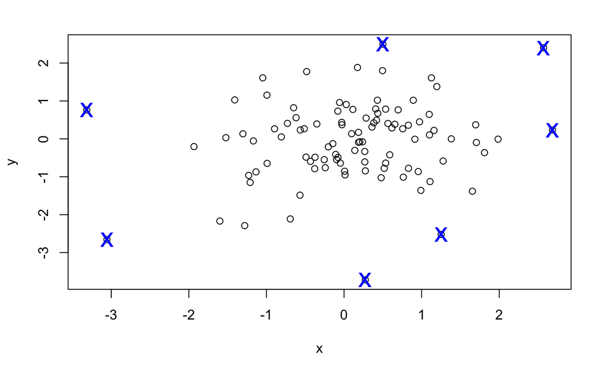

```r
plot(df)
points(df[outlier_list_2,],
       col = "blue", pch = "x", cex = 2)
```

## Outlier Detection with LOF

LOF (Local Outlier Factor) is an algorithm for identifying density-based local outliers (Breunig et al., 2000)[^1]. With LOF, the local density of a point is compared with that of its neighbors. If the former is significantly lower than the latter (with an LOF value greater than one), the point is in a sparser region than its neighbors, which suggests it be an outlier. Below we use the `lof()` implementation included in the `dbscan` package.

```r
library(dbscan)
```

An example using the `iris` dataset

```r
# remove "Species", which is a categorical column
iris_2 <- iris[, 1:4]
```

Use the `lof()` function, which calculates the Local Outlier Factor (LOF) score for each data point using a kd-tree to speed up kNN search. A LOF score of approximately 1 indicates that density around the point is comparable to its neighbors. Scores significantly larger than 1 indicate outliers.

```r
outliers_scores <- lof(iris_2, k = 5)
```

Create a density plot of the different scores

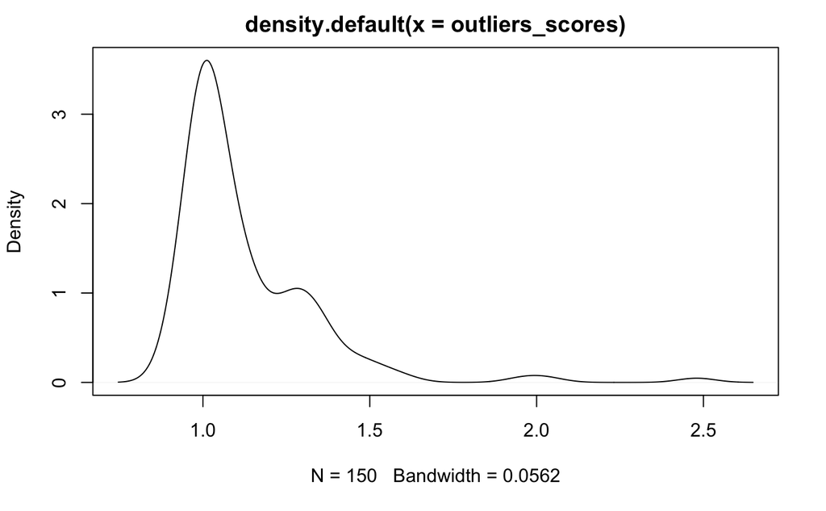

```r
plot(density(outliers_scores))
```

We can easily find out the identity of the outliers, as shown below:

```r
# pick top 5 as outliers
outliers <- order(outliers_scores, decreasing = TRUE)[1:5]
# which ones are outliers?
print(outliers)
```

```
[1]  42 107  23 110  63
```

Check the values of the features for the outliers

```r
iris_2[outliers, ]
```

|  | Sepal.Length | Sepal.Width | Petal.Length | Petal.Width |
| --- | --- | --- | --- | --- |
| 42 | 4.5 | 2.3 | 1.3 | 0.3 |
| 107 | 4.9 | 2.5 | 4.5 | 1.7 |
| 23 | 4.6 | 3.6 | 1.0 | 0.2 |
| 110 | 7.2 | 3.6 | 6.1 | 2.5 |
| 63 | 6.0 | 2.2 | 4.0 | 1.0 |

Next, we show outliers with a *biplot* of the first two *principal components*

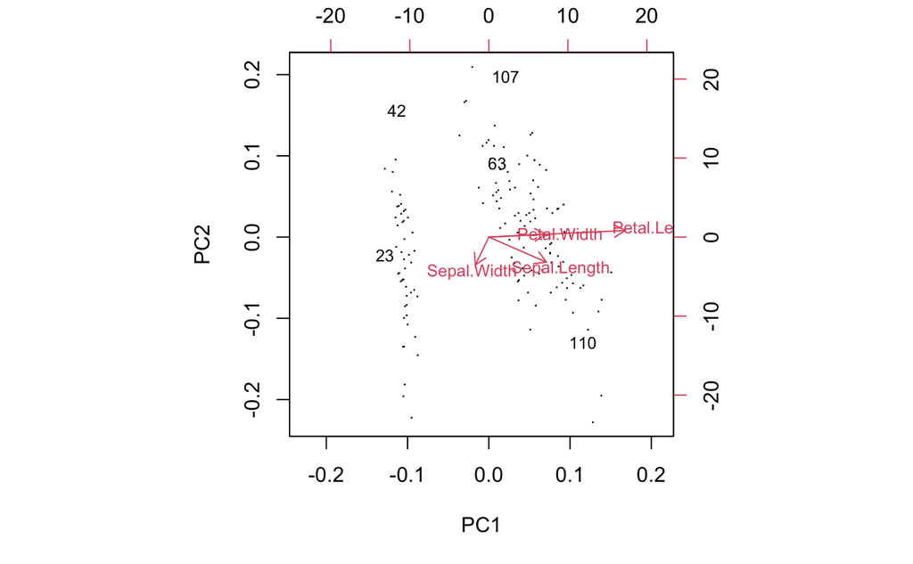

```r
# number of observations
n <- nrow(iris_2)
labels <- 1:n
# label all points EXCEPT outliers with a "."
labels[-outliers] <- "."
# generate biplot
biplot(prcomp(iris_2), cex = .8, xlabs = labels)
```

In the above code, `prcomp()` performs a principal component analysis, and `biplot()` plots the data with its first two principal components. The `x`- and `y`-axis are respectively the first and second principal components, the arrows show the original columns (variables), and the five outliers are labeled with their row numbers.

## Outlier Detection by Clustering

Another way to detect outliers is clustering. By grouping data into clusters, those data not assigned to any clusters are taken as outliers. For example, with density-based clustering such as DBSCAN (Ester et al., 1996)[^2], objects are grouped into one cluster if they are connected to one another by *densely populated areas*. Therefore, objects not assigned to any clusters are isolated from other objects and are taken as outliers.

We can also detect outliers with the k-means algorithm. With k-means, the data are partitioned into $k$ groups by assigning them to the closest cluster *centers*. After that, we can calculate the distance (or dissimilarity) between each object and its cluster center, and pick those with largest distances as outliers.

```r
# perform k-means with 3 groups
kmeans_result <- kmeans(iris_2, centers = 3)
# get cluster centers
kmeans_result$centers
```

```
  Sepal.Length Sepal.Width Petal.Length Petal.Width
1     5.901613    2.748387     4.393548    1.433871
2     6.850000    3.073684     5.742105    2.071053
3     5.006000    3.428000     1.462000    0.246000
```

To see the assignment to each cluster explore the `.$cluster` component of the k-means object:

```r
# cluster IDs
kmeans_result$cluster
```

```
  [1] 3 3 3 3 3 3 3 3 3 3 3 3 3 3 3 3 3 3 3 3 3 3 3 3 3 3 3 3 3 3 3 3 3 3 3 3 3 3 3 3 3 3 3 3 3 3 3 3 3 3 1 1 2 1 1 1 1 1 1 1 1 1 1 1 1 1 1 1 1 1 1 1 1 1 1 1 1 2 1 1 1 1 1 1 1 1 1 1 1 1 1 1
 [93] 1 1 1 1 1 1 1 1 2 1 2 2 2 2 1 2 2 2 2 2 2 1 1 2 2 2 2 1 2 1 2 1 2 2 1 1 2 2 2 2 2 1 2 2 2 2 1 2 2 2 1 2 2 2 1 2 2 1
```

Below we identify the outliers by first computing the distance from every point to its corresponding center (as found by the k-means algorithm), and then sorting the distance vector to select the top 5 observations that felt far away from the center of their corresponding cluster.

```r
# calculate distances between objects and cluster centers
centers <- kmeans_result$centers[kmeans_result$cluster]
# compute Euclidean distance
km_distances <- sqrt(rowSums((iris_2 - centers)^2))
# pick top 5 largest distances
km_outliers <- order(km_distances, decreasing = TRUE)[1:5]
# which ones are outliers?
print(km_outliers)
```

```
[1] 135  53  61 109  78
```

Visualize: let us use `ggplot()` from the `tidyverse` to visualize the results

```r
library(tidyverse)
```

Visualize

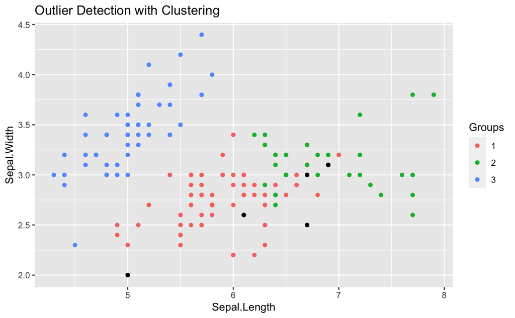

```r
ggplot()+
  geom_point(data=iris_2, aes(x = Sepal.Length, y = Sepal.Width,
                 color = factor(kmeans_result$cluster))) +
  geom_point(aes(x = iris_2[km_outliers, "Sepal.Length"],
                 y = iris_2[km_outliers, "Sepal.Width"]),
             color = "black") +
  labs(title = "Outlier Detection with Clustering",
       color = "Groups")
```

[^1]: Breunig, M. M., Kriegel, H.-P., Ng, R. T., and Sander, J. (2000). LOF: identifying density-based local outliers. In SIGMOD ’00: Proceedings of the 2000 ACM SIG-MOD international conference on Management of data, pages 93-104, New York, NY, USA. ACM Press.
[^2]: Ester, M., Kriegel, H.-P., Sander, J., and Xu, X. (1996). A density-based algorithm for discovering clusters in large spatial databases with noise. In KDD, pages 226-231.